# Face Generation

In this project, you'll use generative adversarial networks to generate new images of faces.

### Get the Data

You'll be using two datasets in this project:

- MNIST
- CelebA

Since the celebA dataset is complex and you're doing GANs in a project for the first time, we want you to test your neural network on MNIST before CelebA. Running the GANs on MNIST will allow you to see how well your model trains sooner.

If you're using [FloydHub](https://www.floydhub.com/), set `data_dir` to "/input" and use the [FloydHub data ID](http://docs.floydhub.com/home/using_datasets/) "R5KrjnANiKVhLWAkpXhNBe".

```python
data_dir = './data'

# FloydHub - Use with data ID "R5KrjnANiKVhLWAkpXhNBe"
#data_dir = '/input'


"""
DON'T MODIFY ANYTHING IN THIS CELL
"""
import helper

helper.download_extract('mnist', data_dir)
helper.download_extract('celeba', data_dir)
```

```
Found mnist Data
Found celeba Data
```

## Explore the Data

### MNIST

As you're aware, the [MNIST](http://yann.lecun.com/exdb/mnist/) dataset contains images of handwritten digits. You can view the first number of examples by changing `show_n_images`.

```python
show_n_images = 25

"""
DON'T MODIFY ANYTHING IN THIS CELL
"""
%matplotlib inline
import os
from glob import glob
from matplotlib import pyplot

mnist_images = helper.get_batch(glob(os.path.join(data_dir, 'mnist/*.jpg'))[:show_n_images], 28, 28, 'L')
pyplot.imshow(helper.images_square_grid(mnist_images, 'L'), cmap='gray')
```

[output not shown]

### CelebA

The [CelebFaces Attributes Dataset (CelebA)](http://mmlab.ie.cuhk.edu.hk/projects/CelebA.html) dataset contains over 200,000 celebrity images with annotations. Since you're going to be generating faces, you won't need the annotations. You can view the first number of examples by changing `show_n_images`.

```python
show_n_images = 25

"""
DON'T MODIFY ANYTHING IN THIS CELL
"""
mnist_images = helper.get_batch(glob(os.path.join(data_dir, 'img_align_celeba/*.jpg'))[:show_n_images], 28, 28, 'RGB')
pyplot.imshow(helper.images_square_grid(mnist_images, 'RGB'))
```

[output not shown]

## Preprocess the Data

Since the project's main focus is on building the GANs, we'll preprocess the data for you. The values of the MNIST and CelebA dataset will be in the range of -0.5 to 0.5 of 28x28 dimensional images. The CelebA images will be cropped to remove parts of the image that don't include a face, then resized down to 28x28.

The MNIST images are black and white images with a single color channel while the CelebA images have 3 color channels (RGB color channel).

## Build the Neural Network

You'll build the components necessary to build a GANs by implementing the following functions below:

- `model_inputs`
- `discriminator`
- `generator`
- `model_loss`
- `model_opt`
- `train`

### Check the Version of TensorFlow and Access to GPU

This will check to make sure you have the correct version of TensorFlow and access to a GPU

```python
"""
DON'T MODIFY ANYTHING IN THIS CELL
"""
from distutils.version import LooseVersion
import warnings
import tensorflow as tf

# Check TensorFlow Version
assert LooseVersion(tf.__version__) >= LooseVersion('1.0'), 'Please use TensorFlow version 1.0 or newer.  You are using {}'.format(tf.__version__)
print('TensorFlow Version: {}'.format(tf.__version__))

# Check for a GPU
if not tf.test.gpu_device_name():
    warnings.warn('No GPU found. Please use a GPU to train your neural network.')
else:
    print('Default GPU Device: {}'.format(tf.test.gpu_device_name()))
```

```
TensorFlow Version: 1.1.0
Default GPU Device: /gpu:0
```

### Input

Implement the `model_inputs` function to create TF Placeholders for the Neural Network. It should create the following placeholders:

- Real input images placeholder with rank 4 using `image_width`, `image_height`, and `image_channels`.
- Z input placeholder with rank 2 using `z_dim`.
- Learning rate placeholder with rank 0.

Return the placeholders in the following the tuple (tensor of real input images, tensor of z data)

```python
import problem_unittests as tests

def model_inputs(image_width, image_height, image_channels, z_dim):
    """
    Create the model inputs
    :param image_width: The input image width
    :param image_height: The input image height
    :param image_channels: The number of image channels
    :param z_dim: The dimension of Z
    :return: Tuple of (tensor of real input images, tensor of z data, learning rate)
    """
    # TODO: Implement Function
    real_inputs = tf.placeholder(
        tf.float32,
        [None, image_width, image_height, image_channels], name='real_inputs')

    z_inputs = tf.placeholder(tf.float32, [None, z_dim], name='z_inputs')

    learning_rate = tf.placeholder(tf.float32, name='learning_rate')

    return real_inputs, z_inputs, learning_rate


"""
DON'T MODIFY ANYTHING IN THIS CELL THAT IS BELOW THIS LINE
"""
tests.test_model_inputs(model_inputs)
```

```
Tests Passed
```

### Discriminator

Implement `discriminator` to create a discriminator neural network that discriminates on `images`. This function should be able to reuse the variables in the neural network. Use [`tf.variable_scope`](https://www.tensorflow.org/api_docs/python/tf/variable_scope) with a scope name of "discriminator" to allow the variables to be reused. The function should return a tuple of (tensor output of the discriminator, tensor logits of the discriminator).

```python
def discriminator(images, reuse=False):
    """
    Create the discriminator network
    :param images: Tensor of input image(s)
    :param reuse: Boolean if the weights should be reused
    :return: Tuple of (tensor output of the discriminator, tensor logits of the discriminator)
    """
    # TODO: Implement Function
    alpha = 0.2
    with tf.variable_scope('discriminator', reuse=reuse):
        # Input layer 28x28x3
        x1 = tf.layers.conv2d(
            images,
            64,
            5,
            strides=2,
            padding='same',
            kernel_initializer=tf.contrib.layers.variance_scaling_initializer( # xavier_initializer
                factor=1.0, mode='FAN_AVG', uniform=False))
        relu1 = tf.maximum(alpha * x1, x1)
        # Layer size is 14x14x64

        x2 = tf.layers.conv2d(
            relu1,
            128,
            5,
            strides=2,
            padding='same',
            kernel_initializer=tf.contrib.layers.variance_scaling_initializer(
                factor=1.0, mode='FAN_AVG', uniform=False))
        bn2 = tf.layers.batch_normalization(x2, training=True)
        relu2 = tf.maximum(alpha * bn2, bn2)
        # Layer size is 7x7x128

        x3 = tf.layers.conv2d(
            relu2,
            256,
            5,
            strides=2,
            padding='same',
            kernel_initializer=tf.contrib.layers.variance_scaling_initializer(
                factor=1.0, mode='FAN_AVG', uniform=False))
        bn3 = tf.layers.batch_normalization(x3, training=True)
        relu3 = tf.maximum(alpha * bn3, bn3)
        # Layer size is 4x4x256

        x4 = tf.layers.conv2d(
            relu3,
            512,
            5,
            strides=2,
            padding='same',
            kernel_initializer=tf.contrib.layers.variance_scaling_initializer(
                factor=1.0, mode='FAN_AVG', uniform=False))
        bn4 = tf.layers.batch_normalization(x4, training=True)
        relu4 = tf.maximum(alpha * bn4, bn4)
        # Layer size is 2x2x512

        flat = tf.reshape(relu4, (-1, 2*2*512))
        logits = tf.layers.dense(flat, 1)
        out = tf.sigmoid(logits)

    return out, logits


"""
DON'T MODIFY ANYTHING IN THIS CELL THAT IS BELOW THIS LINE
"""
tests.test_discriminator(discriminator, tf)
```

```
Tests Passed
```

### Generator

Implement `generator` to generate an image using `z`. This function should be able to reuse the variables in the neural network. Use [`tf.variable_scope`](https://www.tensorflow.org/api_docs/python/tf/variable_scope) with a scope name of "generator" to allow the variables to be reused. The function should return the generated 28 x 28 x `out_channel_dim` images.

```python
def generator(z, out_channel_dim, is_train=True):
    """
    Create the generator network
    :param z: Input z
    :param out_channel_dim: The number of channels in the output image
    :param is_train: Boolean if generator is being used for training
    :return: The tensor output of the generator
    """
    alpha = 0.2
    keep_prob = 0.5
    # TODO: Implement Function
    with tf.variable_scope('generator', reuse = not is_train):
        x1 = tf.layers.dense(z, 7*7*512)

        x1 = tf.reshape(x1, (-1, 7, 7, 512))
        bn1 = tf.layers.batch_normalization(x1, training=is_train)
        relu1 = tf.nn.relu(bn1)
        # Layer size 7x7x512

        x2 = tf.layers.conv2d_transpose(
            relu1,
            256,
            5,
            strides=2,
            padding='same',
            kernel_initializer=tf.contrib.layers.xavier_initializer_conv2d())
        bn2 = tf.layers.batch_normalization(x2, training=is_train)
        relu2 = tf.nn.relu(bn2)
        # Layer size 14x14x256

        x3 = tf.layers.conv2d_transpose(
            relu2,
            128,
            5,
            strides=2,
            padding='same',
            kernel_initializer=tf.contrib.layers.xavier_initializer_conv2d())
        bn3 = tf.layers.batch_normalization(x3, training=is_train)
        relu3 = tf.nn.relu(bn3)
        drop3 = tf.nn.dropout(relu3, keep_prob)
        # Layer size 28x28x128

        logits = tf.layers.conv2d_transpose(
            drop3,
            out_channel_dim,
            5,
            strides=1,
            padding='same',
            kernel_initializer=tf.contrib.layers.xavier_initializer_conv2d())
        # Layer size 28x28x(out_channel_dim)

        #out = tf.nn.dropout(tf.tanh(logits), keep_prob)
        out = tf.tanh(logits)

    return out


"""
DON'T MODIFY ANYTHING IN THIS CELL THAT IS BELOW THIS LINE
"""
tests.test_generator(generator, tf)
```

```
Tests Passed
```

### Loss

Implement `model_loss` to build the GANs for training and calculate the loss. The function should return a tuple of (discriminator loss, generator loss). Use the following functions you implemented:

- `discriminator(images, reuse=False)`
- `generator(z, out_channel_dim, is_train=True)`

```python
def model_loss(input_real, input_z, out_channel_dim):
    """
    Get the loss for the discriminator and generator
    :param input_real: Images from the real dataset
    :param input_z: Z input
    :param out_channel_dim: The number of channels in the output image
    :return: A tuple of (discriminator loss, generator loss)
    """
    # TODO: Implement Function
    smooth = 0.1
    g_model = generator(input_z, out_channel_dim)
    d_model_real, d_logits_real = discriminator(input_real)
    d_model_fake, d_logits_fake = discriminator(g_model, reuse=True)

    d_loss_real = tf.reduce_mean(
        tf.nn.sigmoid_cross_entropy_with_logits(
            logits=d_logits_real, labels=tf.ones_like(d_logits_real) * (1 - smooth)))
    d_loss_fake = tf.reduce_mean(
        tf.nn.sigmoid_cross_entropy_with_logits(
            logits=d_logits_fake, labels=tf.zeros_like(d_model_fake)))

    g_loss = tf.reduce_mean(
        tf.nn.sigmoid_cross_entropy_with_logits(
            logits=d_logits_fake, labels=tf.ones_like(d_model_fake)))

    d_loss = d_loss_real + d_loss_fake

    return d_loss, g_loss


"""
DON'T MODIFY ANYTHING IN THIS CELL THAT IS BELOW THIS LINE
"""
tests.test_model_loss(model_loss)
```

```
Tests Passed
```

### Optimization

Implement `model_opt` to create the optimization operations for the GANs. Use [`tf.trainable_variables`](https://www.tensorflow.org/api_docs/python/tf/trainable_variables) to get all the trainable variables. Filter the variables with names that are in the discriminator and generator scope names. The function should return a tuple of (discriminator training operation, generator training operation).

```python
def model_opt(d_loss, g_loss, learning_rate, beta1):
    """
    Get optimization operations
    :param d_loss: Discriminator loss Tensor
    :param g_loss: Generator loss Tensor
    :param learning_rate: Learning Rate Placeholder
    :param beta1: The exponential decay rate for the 1st moment in the optimizer
    :return: A tuple of (discriminator training operation, generator training operation)
    """
    # TODO: Implement Function
    trainable_vars = tf.trainable_variables()
    d_vars = list(filter(lambda x: x.name.startswith('discriminator'), trainable_vars))
    g_vars = list(filter(lambda x: x.name.startswith('generator'), trainable_vars))

    with tf.control_dependencies(tf.get_collection(tf.GraphKeys.UPDATE_OPS)):
        d_train_opt = tf.train.AdamOptimizer(learning_rate, beta1=beta1).minimize(d_loss, var_list=d_vars)
        g_train_opt = tf.train.AdamOptimizer(learning_rate, beta1=beta1).minimize(g_loss, var_list=g_vars)

    return d_train_opt, g_train_opt


"""
DON'T MODIFY ANYTHING IN THIS CELL THAT IS BELOW THIS LINE
"""
tests.test_model_opt(model_opt, tf)
```

```
Tests Passed
```

## Neural Network Training

### Show Output

Use this function to show the current output of the generator during training. It will help you determine how well the GANs is training.

```python
"""
DON'T MODIFY ANYTHING IN THIS CELL
"""
import numpy as np

def show_generator_output(sess, n_images, input_z, out_channel_dim, image_mode):
    """
    Show example output for the generator
    :param sess: TensorFlow session
    :param n_images: Number of Images to display
    :param input_z: Input Z Tensor
    :param out_channel_dim: The number of channels in the output image
    :param image_mode: The mode to use for images ("RGB" or "L")
    """
    cmap = None if image_mode == 'RGB' else 'gray'
    z_dim = input_z.get_shape().as_list()[-1]
    example_z = np.random.uniform(-1, 1, size=[n_images, z_dim])

    samples = sess.run(
        generator(input_z, out_channel_dim, False),
        feed_dict={input_z: example_z})

    images_grid = helper.images_square_grid(samples, image_mode)
    pyplot.imshow(images_grid, cmap=cmap)
    pyplot.show()
```

### Train

Implement `train` to build and train the GANs. Use the following functions you implemented:

- `model_inputs(image_width, image_height, image_channels, z_dim)`
- `model_loss(input_real, input_z, out_channel_dim)`
- `model_opt(d_loss, g_loss, learning_rate, beta1)`

Use the `show_generator_output` to show `generator` output while you train. Running `show_generator_output` for every batch will drastically increase training time and increase the size of the notebook. It's recommended to print the `generator` output every 100 batches.

```python
def train(epoch_count, batch_size, z_dim, learning_rate, beta1, get_batches, data_shape, data_image_mode):
    """
    Train the GAN
    :param epoch_count: Number of epochs
    :param batch_size: Batch Size
    :param z_dim: Z dimension
    :param learning_rate: Learning Rate
    :param beta1: The exponential decay rate for the 1st moment in the optimizer
    :param get_batches: Function to get batches
    :param data_shape: Shape of the data
    :param data_image_mode: The image mode to use for images ("RGB" or "L")
    """
    # TODO: Build Model
    _, input_width, input_height, input_channels = data_shape
    real_inputs, z_inputs, l_rate = model_inputs(
            input_width, input_height, input_channels, z_dim)
    d_loss, g_loss = model_loss(real_inputs, z_inputs, input_channels)
    d_train_opt, g_train_opt = model_opt(d_loss, g_loss, l_rate, beta1)

    steps = 0

    with tf.Session() as sess:
        sess.run(tf.global_variables_initializer())
        for epoch_i in range(epoch_count):
            for batch_images in get_batches(batch_size):
                # TODO: Train Model
                steps += 1

                batch_images = batch_images*2
                # Generate noise
                batch_z = np.random.uniform(-1, 1, size=(batch_size, z_dim))

                # Run optimizers
                _ = sess.run(d_train_opt, feed_dict={
                        real_inputs: batch_images,
                        z_inputs: batch_z,
                        l_rate: learning_rate})

                _ = sess.run(g_train_opt, feed_dict={
                        real_inputs: batch_images,
                        z_inputs: batch_z,
                        l_rate: learning_rate})

                if steps % 10 == 0:
                    dis_loss = sess.run(d_loss, feed_dict={z_inputs: batch_z, real_inputs: batch_images})
                    gen_loss = sess.run(g_loss, feed_dict={z_inputs: batch_z})

                    print(
                        'Epoch: {:<5}'.format(epoch_i),
                        'Step: {:<5}'.format(steps),
                        'Dicriminator Loss: {:<10.6f}'.format(dis_loss),
                        'Generator Loss: {:<10.6f}'.format(gen_loss))

                if steps % 100 == 0:
                    show_generator_output(sess, 40, z_inputs, input_channels, data_image_mode)
```

### MNIST

Test your GANs architecture on MNIST. After 2 epochs, the GANs should be able to generate images that look like handwritten digits. Make sure the loss of the generator is lower than the loss of the discriminator or close to 0.

```
Epoch: 0     Step: 10    Dicriminator Loss: 1.284361   Generator Loss: 0.782676
Epoch: 0     Step: 20    Dicriminator Loss: 0.794594   Generator Loss: 11.043351
Epoch: 0     Step: 30    Dicriminator Loss: 1.136684   Generator Loss: 0.757018
Epoch: 0     Step: 40    Dicriminator Loss: 0.664087   Generator Loss: 1.810310
Epoch: 0     Step: 50    Dicriminator Loss: 0.568936   Generator Loss: 1.820369
Epoch: 0     Step: 60    Dicriminator Loss: 0.788402   Generator Loss: 1.402641
Epoch: 0     Step: 70    Dicriminator Loss: 0.624040   Generator Loss: 2.489089
Epoch: 0     Step: 80    Dicriminator Loss: 0.946204   Generator Loss: 1.297738
Epoch: 0     Step: 90    Dicriminator Loss: 1.048311   Generator Loss: 0.764029
Epoch: 0     Step: 100   Dicriminator Loss: 1.446032   Generator Loss: 0.624743
```

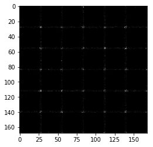

```
Epoch: 0     Step: 110   Dicriminator Loss: 0.868728   Generator Loss: 2.224088
Epoch: 0     Step: 120   Dicriminator Loss: 1.496288   Generator Loss: 0.475346
Epoch: 0     Step: 130   Dicriminator Loss: 0.821094   Generator Loss: 1.242583
Epoch: 0     Step: 140   Dicriminator Loss: 1.268822   Generator Loss: 2.629446
Epoch: 0     Step: 150   Dicriminator Loss: 1.235721   Generator Loss: 0.636232
Epoch: 0     Step: 160   Dicriminator Loss: 1.122905   Generator Loss: 0.646407
Epoch: 0     Step: 170   Dicriminator Loss: 1.325679   Generator Loss: 0.597533
Epoch: 0     Step: 180   Dicriminator Loss: 1.229948   Generator Loss: 3.045635
Epoch: 0     Step: 190   Dicriminator Loss: 0.650478   Generator Loss: 1.713121
Epoch: 0     Step: 200   Dicriminator Loss: 0.793447   Generator Loss: 1.568766
```

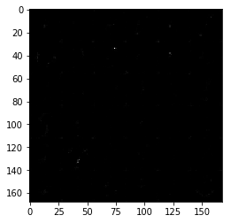

```
Epoch: 0     Step: 210   Dicriminator Loss: 0.909435   Generator Loss: 0.900930
Epoch: 0     Step: 220   Dicriminator Loss: 1.040441   Generator Loss: 2.810553
Epoch: 0     Step: 230   Dicriminator Loss: 0.914753   Generator Loss: 1.070175
Epoch: 0     Step: 240   Dicriminator Loss: 0.777282   Generator Loss: 1.261069
Epoch: 0     Step: 250   Dicriminator Loss: 0.878791   Generator Loss: 1.517948
Epoch: 0     Step: 260   Dicriminator Loss: 1.090309   Generator Loss: 0.761018
Epoch: 0     Step: 270   Dicriminator Loss: 0.911400   Generator Loss: 1.442875
Epoch: 0     Step: 280   Dicriminator Loss: 0.878523   Generator Loss: 1.915350
Epoch: 0     Step: 290   Dicriminator Loss: 0.928625   Generator Loss: 1.043355
Epoch: 0     Step: 300   Dicriminator Loss: 0.809440   Generator Loss: 1.486645
```

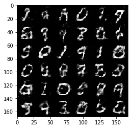

```
Epoch: 0     Step: 310   Dicriminator Loss: 1.031739   Generator Loss: 0.938247
Epoch: 0     Step: 320   Dicriminator Loss: 0.914752   Generator Loss: 1.351595
Epoch: 0     Step: 330   Dicriminator Loss: 0.915109   Generator Loss: 1.165085
Epoch: 0     Step: 340   Dicriminator Loss: 0.848201   Generator Loss: 1.089765
Epoch: 0     Step: 350   Dicriminator Loss: 0.817865   Generator Loss: 1.245234
Epoch: 0     Step: 360   Dicriminator Loss: 0.997426   Generator Loss: 1.815246
Epoch: 0     Step: 370   Dicriminator Loss: 0.969561   Generator Loss: 1.877551
Epoch: 0     Step: 380   Dicriminator Loss: 1.086585   Generator Loss: 2.783112
Epoch: 0     Step: 390   Dicriminator Loss: 1.229249   Generator Loss: 2.080149
Epoch: 0     Step: 400   Dicriminator Loss: 0.961671   Generator Loss: 1.239116
```

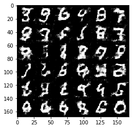

```
Epoch: 0     Step: 410   Dicriminator Loss: 1.573206   Generator Loss: 0.410582
Epoch: 0     Step: 420   Dicriminator Loss: 0.898976   Generator Loss: 1.353629
Epoch: 0     Step: 430   Dicriminator Loss: 0.955526   Generator Loss: 1.664180
Epoch: 0     Step: 440   Dicriminator Loss: 1.036621   Generator Loss: 0.923405
Epoch: 0     Step: 450   Dicriminator Loss: 1.166419   Generator Loss: 1.213570
Epoch: 0     Step: 460   Dicriminator Loss: 1.381136   Generator Loss: 2.804199
Epoch: 0     Step: 470   Dicriminator Loss: 1.134072   Generator Loss: 2.174257
Epoch: 0     Step: 480   Dicriminator Loss: 0.827743   Generator Loss: 1.205121
Epoch: 0     Step: 490   Dicriminator Loss: 1.566122   Generator Loss: 0.394741
Epoch: 0     Step: 500   Dicriminator Loss: 1.104498   Generator Loss: 0.775139
```

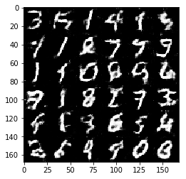

```
Epoch: 0     Step: 510   Dicriminator Loss: 1.136497   Generator Loss: 0.778171
Epoch: 0     Step: 520   Dicriminator Loss: 0.881192   Generator Loss: 1.288410
Epoch: 0     Step: 530   Dicriminator Loss: 0.881192   Generator Loss: 1.075498
Epoch: 0     Step: 540   Dicriminator Loss: 0.868642   Generator Loss: 1.137504
Epoch: 0     Step: 550   Dicriminator Loss: 0.918913   Generator Loss: 1.380780
Epoch: 0     Step: 560   Dicriminator Loss: 1.091551   Generator Loss: 0.687331
Epoch: 0     Step: 570   Dicriminator Loss: 0.920833   Generator Loss: 1.893248
Epoch: 0     Step: 580   Dicriminator Loss: 0.989529   Generator Loss: 1.248914
Epoch: 0     Step: 590   Dicriminator Loss: 1.388512   Generator Loss: 0.527740
Epoch: 0     Step: 600   Dicriminator Loss: 1.152484   Generator Loss: 0.699022
```

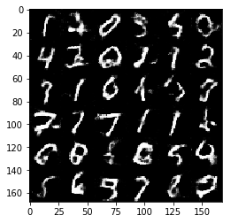

```
Epoch: 0     Step: 610   Dicriminator Loss: 1.494891   Generator Loss: 0.414834
Epoch: 0     Step: 620   Dicriminator Loss: 1.296668   Generator Loss: 0.602216
Epoch: 0     Step: 630   Dicriminator Loss: 0.809640   Generator Loss: 1.840776
Epoch: 0     Step: 640   Dicriminator Loss: 0.858924   Generator Loss: 1.062299
Epoch: 0     Step: 650   Dicriminator Loss: 1.230946   Generator Loss: 0.636147
Epoch: 0     Step: 660   Dicriminator Loss: 0.927670   Generator Loss: 0.933420
Epoch: 0     Step: 670   Dicriminator Loss: 1.407439   Generator Loss: 2.599193
Epoch: 0     Step: 680   Dicriminator Loss: 1.394761   Generator Loss: 0.513170
Epoch: 0     Step: 690   Dicriminator Loss: 0.913366   Generator Loss: 1.053188
Epoch: 0     Step: 700   Dicriminator Loss: 0.747727   Generator Loss: 1.542124
```

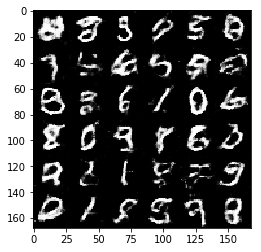

```
Epoch: 0     Step: 710   Dicriminator Loss: 0.987819   Generator Loss: 0.809781
Epoch: 0     Step: 720   Dicriminator Loss: 1.109232   Generator Loss: 0.737843
Epoch: 0     Step: 730   Dicriminator Loss: 1.025509   Generator Loss: 1.064517
Epoch: 0     Step: 740   Dicriminator Loss: 1.117307   Generator Loss: 0.730765
Epoch: 0     Step: 750   Dicriminator Loss: 0.880566   Generator Loss: 0.955400
Epoch: 0     Step: 760   Dicriminator Loss: 0.948655   Generator Loss: 1.276352
Epoch: 0     Step: 770   Dicriminator Loss: 1.129118   Generator Loss: 2.966015
Epoch: 0     Step: 780   Dicriminator Loss: 0.918757   Generator Loss: 1.117471
Epoch: 0     Step: 790   Dicriminator Loss: 0.915823   Generator Loss: 1.645715
Epoch: 0     Step: 800   Dicriminator Loss: 0.894367   Generator Loss: 0.937671
```

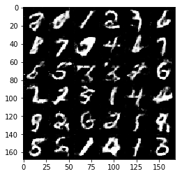

```
Epoch: 0     Step: 810   Dicriminator Loss: 0.973150   Generator Loss: 2.093636
Epoch: 0     Step: 820   Dicriminator Loss: 1.427826   Generator Loss: 0.527211
Epoch: 0     Step: 830   Dicriminator Loss: 0.872022   Generator Loss: 1.194452
Epoch: 0     Step: 840   Dicriminator Loss: 0.986701   Generator Loss: 0.834250
Epoch: 0     Step: 850   Dicriminator Loss: 1.624690   Generator Loss: 0.390954
Epoch: 0     Step: 860   Dicriminator Loss: 1.011235   Generator Loss: 0.810876
Epoch: 0     Step: 870   Dicriminator Loss: 0.981399   Generator Loss: 0.903104
Epoch: 0     Step: 880   Dicriminator Loss: 0.854612   Generator Loss: 1.355880
Epoch: 0     Step: 890   Dicriminator Loss: 0.932910   Generator Loss: 1.587134
Epoch: 0     Step: 900   Dicriminator Loss: 1.058302   Generator Loss: 0.847443
```

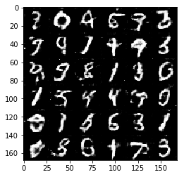

```
Epoch: 0     Step: 910   Dicriminator Loss: 1.409999   Generator Loss: 0.454035
Epoch: 0     Step: 920   Dicriminator Loss: 0.846595   Generator Loss: 1.483654
Epoch: 0     Step: 930   Dicriminator Loss: 0.992580   Generator Loss: 1.654502
Epoch: 1     Step: 940   Dicriminator Loss: 0.896122   Generator Loss: 1.130672
Epoch: 1     Step: 950   Dicriminator Loss: 1.491879   Generator Loss: 0.474440
Epoch: 1     Step: 960   Dicriminator Loss: 0.832252   Generator Loss: 1.155725
Epoch: 1     Step: 970   Dicriminator Loss: 1.496399   Generator Loss: 0.497497
Epoch: 1     Step: 980   Dicriminator Loss: 0.988650   Generator Loss: 0.841738
Epoch: 1     Step: 990   Dicriminator Loss: 0.846748   Generator Loss: 1.203732
Epoch: 1     Step: 1000  Dicriminator Loss: 0.949226   Generator Loss: 0.948368
```

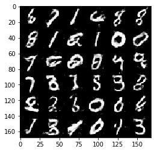

```
Epoch: 1     Step: 1010  Dicriminator Loss: 1.075654   Generator Loss: 1.610261
Epoch: 1     Step: 1020  Dicriminator Loss: 1.126695   Generator Loss: 0.666907
Epoch: 1     Step: 1030  Dicriminator Loss: 1.292116   Generator Loss: 0.571493
Epoch: 1     Step: 1040  Dicriminator Loss: 0.722950   Generator Loss: 1.539143
Epoch: 1     Step: 1050  Dicriminator Loss: 1.212491   Generator Loss: 0.654428
Epoch: 1     Step: 1060  Dicriminator Loss: 1.122375   Generator Loss: 0.711753
Epoch: 1     Step: 1070  Dicriminator Loss: 0.810624   Generator Loss: 1.117377
Epoch: 1     Step: 1080  Dicriminator Loss: 0.894666   Generator Loss: 1.102682
Epoch: 1     Step: 1090  Dicriminator Loss: 1.411734   Generator Loss: 0.545948
Epoch: 1     Step: 1100  Dicriminator Loss: 1.442513   Generator Loss: 0.451271
```

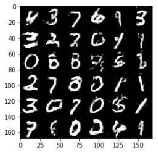

```
Epoch: 1     Step: 1110  Dicriminator Loss: 0.849481   Generator Loss: 1.131374
Epoch: 1     Step: 1120  Dicriminator Loss: 0.701801   Generator Loss: 2.216623
Epoch: 1     Step: 1130  Dicriminator Loss: 0.918441   Generator Loss: 1.101879
Epoch: 1     Step: 1140  Dicriminator Loss: 0.974171   Generator Loss: 0.918313
Epoch: 1     Step: 1150  Dicriminator Loss: 0.859842   Generator Loss: 1.316369
Epoch: 1     Step: 1160  Dicriminator Loss: 1.066821   Generator Loss: 0.801044
Epoch: 1     Step: 1170  Dicriminator Loss: 0.759459   Generator Loss: 1.688409
Epoch: 1     Step: 1180  Dicriminator Loss: 0.765272   Generator Loss: 1.288798
Epoch: 1     Step: 1190  Dicriminator Loss: 1.133453   Generator Loss: 0.624438
Epoch: 1     Step: 1200  Dicriminator Loss: 0.994105   Generator Loss: 0.981688
```

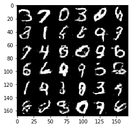

```
Epoch: 1     Step: 1210  Dicriminator Loss: 0.813040   Generator Loss: 1.028263
Epoch: 1     Step: 1220  Dicriminator Loss: 1.194516   Generator Loss: 0.650149
Epoch: 1     Step: 1230  Dicriminator Loss: 0.790017   Generator Loss: 1.171378
Epoch: 1     Step: 1240  Dicriminator Loss: 1.353231   Generator Loss: 0.518348
Epoch: 1     Step: 1250  Dicriminator Loss: 0.977772   Generator Loss: 0.811167
Epoch: 1     Step: 1260  Dicriminator Loss: 1.471806   Generator Loss: 2.677961
Epoch: 1     Step: 1270  Dicriminator Loss: 0.991198   Generator Loss: 0.971440
Epoch: 1     Step: 1280  Dicriminator Loss: 0.819245   Generator Loss: 1.054827
Epoch: 1     Step: 1290  Dicriminator Loss: 0.687393   Generator Loss: 1.458099
Epoch: 1     Step: 1300  Dicriminator Loss: 0.817608   Generator Loss: 1.257111
```

[6 more figures not shown]

```
Epoch: 1     Step: 1810  Dicriminator Loss: 1.445677   Generator Loss: 0.503333
Epoch: 1     Step: 1820  Dicriminator Loss: 1.169175   Generator Loss: 0.682424
Epoch: 1     Step: 1830  Dicriminator Loss: 0.985312   Generator Loss: 0.813164
Epoch: 1     Step: 1840  Dicriminator Loss: 0.643088   Generator Loss: 1.659687
Epoch: 1     Step: 1850  Dicriminator Loss: 0.732302   Generator Loss: 1.297944
Epoch: 1     Step: 1860  Dicriminator Loss: 0.880976   Generator Loss: 0.938027
Epoch: 1     Step: 1870  Dicriminator Loss: 0.606649   Generator Loss: 1.441026
```

```python
batch_size = 64
z_dim = 100
learning_rate = 0.0002
beta1 = 0.5

"""
DON'T MODIFY ANYTHING IN THIS CELL THAT IS BELOW THIS LINE
"""
epochs = 2

mnist_dataset = helper.Dataset('mnist', glob(os.path.join(data_dir, 'mnist/*.jpg')))
with tf.Graph().as_default():
    train(epochs, batch_size, z_dim, learning_rate, beta1, mnist_dataset.get_batches,
          mnist_dataset.shape, mnist_dataset.image_mode)
```

### CelebA

Run your GANs on CelebA. It will take around 20 minutes on the average GPU to run one epoch. You can run the whole epoch or stop when it starts to generate realistic faces.

```
Epoch: 0     Step: 10    Dicriminator Loss: 0.434867   Generator Loss: 5.627146
Epoch: 0     Step: 20    Dicriminator Loss: 1.191125   Generator Loss: 1.562181
Epoch: 0     Step: 30    Dicriminator Loss: 1.257088   Generator Loss: 9.055113
Epoch: 0     Step: 40    Dicriminator Loss: 0.595142   Generator Loss: 2.216605
Epoch: 0     Step: 50    Dicriminator Loss: 1.700584   Generator Loss: 7.542442
Epoch: 0     Step: 60    Dicriminator Loss: 0.464584   Generator Loss: 3.127132
Epoch: 0     Step: 70    Dicriminator Loss: 0.615438   Generator Loss: 1.716500
Epoch: 0     Step: 80    Dicriminator Loss: 0.426492   Generator Loss: 2.826637
Epoch: 0     Step: 90    Dicriminator Loss: 0.382839   Generator Loss: 3.458575
Epoch: 0     Step: 100   Dicriminator Loss: 0.448858   Generator Loss: 3.561017
```

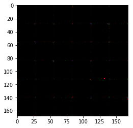

```
Epoch: 0     Step: 110   Dicriminator Loss: 0.505314   Generator Loss: 3.836782
Epoch: 0     Step: 120   Dicriminator Loss: 1.024293   Generator Loss: 1.024686
Epoch: 0     Step: 130   Dicriminator Loss: 0.458257   Generator Loss: 2.833764
Epoch: 0     Step: 140   Dicriminator Loss: 0.457340   Generator Loss: 2.749897
Epoch: 0     Step: 150   Dicriminator Loss: 0.436683   Generator Loss: 2.519269
Epoch: 0     Step: 160   Dicriminator Loss: 0.433834   Generator Loss: 2.732253
Epoch: 0     Step: 170   Dicriminator Loss: 0.868877   Generator Loss: 1.094609
Epoch: 0     Step: 180   Dicriminator Loss: 1.436042   Generator Loss: 0.601839
Epoch: 0     Step: 190   Dicriminator Loss: 0.574483   Generator Loss: 1.807628
Epoch: 0     Step: 200   Dicriminator Loss: 0.599393   Generator Loss: 2.516971
```

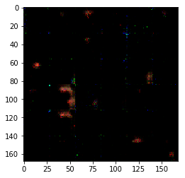

```
Epoch: 0     Step: 210   Dicriminator Loss: 1.673887   Generator Loss: 5.535114
Epoch: 0     Step: 220   Dicriminator Loss: 0.559106   Generator Loss: 2.100822
Epoch: 0     Step: 230   Dicriminator Loss: 0.600395   Generator Loss: 3.449112
Epoch: 0     Step: 240   Dicriminator Loss: 0.481500   Generator Loss: 2.398026
Epoch: 0     Step: 250   Dicriminator Loss: 1.572886   Generator Loss: 5.579393
Epoch: 0     Step: 260   Dicriminator Loss: 0.593527   Generator Loss: 2.585318
Epoch: 0     Step: 270   Dicriminator Loss: 0.578042   Generator Loss: 3.361094
Epoch: 0     Step: 280   Dicriminator Loss: 0.778207   Generator Loss: 2.633596
Epoch: 0     Step: 290   Dicriminator Loss: 0.629805   Generator Loss: 2.964278
Epoch: 0     Step: 300   Dicriminator Loss: 0.599010   Generator Loss: 1.704208
```

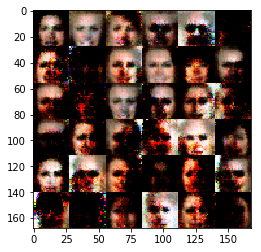

```
Epoch: 0     Step: 310   Dicriminator Loss: 0.749805   Generator Loss: 3.837422
Epoch: 0     Step: 320   Dicriminator Loss: 0.754295   Generator Loss: 1.280024
Epoch: 0     Step: 330   Dicriminator Loss: 0.914765   Generator Loss: 0.980865
Epoch: 0     Step: 340   Dicriminator Loss: 0.789797   Generator Loss: 1.161340
Epoch: 0     Step: 350   Dicriminator Loss: 1.625601   Generator Loss: 0.411266
Epoch: 0     Step: 360   Dicriminator Loss: 2.167691   Generator Loss: 0.236856
Epoch: 0     Step: 370   Dicriminator Loss: 0.607862   Generator Loss: 1.679083
Epoch: 0     Step: 380   Dicriminator Loss: 0.655428   Generator Loss: 1.455080
Epoch: 0     Step: 390   Dicriminator Loss: 0.777493   Generator Loss: 2.198132
Epoch: 0     Step: 400   Dicriminator Loss: 0.651008   Generator Loss: 2.074165
```

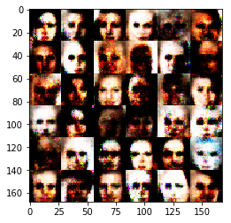

```
Epoch: 0     Step: 410   Dicriminator Loss: 0.878772   Generator Loss: 1.095330
Epoch: 0     Step: 420   Dicriminator Loss: 0.885497   Generator Loss: 2.004365
Epoch: 0     Step: 430   Dicriminator Loss: 1.114843   Generator Loss: 2.641335
Epoch: 0     Step: 440   Dicriminator Loss: 0.848420   Generator Loss: 1.110684
Epoch: 0     Step: 450   Dicriminator Loss: 0.690021   Generator Loss: 1.531835
Epoch: 0     Step: 460   Dicriminator Loss: 0.819696   Generator Loss: 1.233525
Epoch: 0     Step: 470   Dicriminator Loss: 0.687715   Generator Loss: 2.024205
Epoch: 0     Step: 480   Dicriminator Loss: 0.980722   Generator Loss: 0.862419
Epoch: 0     Step: 490   Dicriminator Loss: 0.701541   Generator Loss: 2.282352
Epoch: 0     Step: 500   Dicriminator Loss: 0.778457   Generator Loss: 1.189676
```

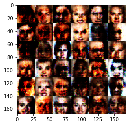

```
Epoch: 0     Step: 510   Dicriminator Loss: 0.864005   Generator Loss: 1.199593
Epoch: 0     Step: 520   Dicriminator Loss: 0.620127   Generator Loss: 1.881512
Epoch: 0     Step: 530   Dicriminator Loss: 0.688372   Generator Loss: 1.389975
Epoch: 0     Step: 540   Dicriminator Loss: 0.843458   Generator Loss: 1.156463
Epoch: 0     Step: 550   Dicriminator Loss: 0.919626   Generator Loss: 0.883103
Epoch: 0     Step: 560   Dicriminator Loss: 0.878198   Generator Loss: 1.041268
Epoch: 0     Step: 570   Dicriminator Loss: 1.319624   Generator Loss: 0.527871
Epoch: 0     Step: 580   Dicriminator Loss: 1.350415   Generator Loss: 3.080360
Epoch: 0     Step: 590   Dicriminator Loss: 0.903625   Generator Loss: 1.703182
Epoch: 0     Step: 600   Dicriminator Loss: 0.882313   Generator Loss: 2.588453
```

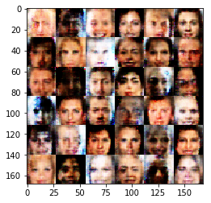

```
Epoch: 0     Step: 610   Dicriminator Loss: 0.986399   Generator Loss: 2.897393
Epoch: 0     Step: 620   Dicriminator Loss: 0.703230   Generator Loss: 1.817446
Epoch: 0     Step: 630   Dicriminator Loss: 1.930087   Generator Loss: 4.113678
Epoch: 0     Step: 640   Dicriminator Loss: 0.969621   Generator Loss: 2.302804
Epoch: 0     Step: 650   Dicriminator Loss: 0.736888   Generator Loss: 1.168007
Epoch: 0     Step: 660   Dicriminator Loss: 0.827117   Generator Loss: 1.120885
Epoch: 0     Step: 670   Dicriminator Loss: 1.050147   Generator Loss: 0.797949
Epoch: 0     Step: 680   Dicriminator Loss: 1.071493   Generator Loss: 0.676593
Epoch: 0     Step: 690   Dicriminator Loss: 0.805738   Generator Loss: 1.190640
Epoch: 0     Step: 700   Dicriminator Loss: 0.985577   Generator Loss: 0.827475
```

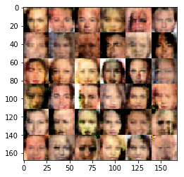

```
Epoch: 0     Step: 710   Dicriminator Loss: 0.772204   Generator Loss: 1.567019
Epoch: 0     Step: 720   Dicriminator Loss: 1.477714   Generator Loss: 0.463452
Epoch: 0     Step: 730   Dicriminator Loss: 0.775337   Generator Loss: 1.738465
Epoch: 0     Step: 740   Dicriminator Loss: 1.054360   Generator Loss: 3.349556
Epoch: 0     Step: 750   Dicriminator Loss: 0.957579   Generator Loss: 1.124787
Epoch: 0     Step: 760   Dicriminator Loss: 0.796516   Generator Loss: 1.425960
Epoch: 0     Step: 770   Dicriminator Loss: 0.915451   Generator Loss: 1.683628
Epoch: 0     Step: 780   Dicriminator Loss: 2.060044   Generator Loss: 0.231102
Epoch: 0     Step: 790   Dicriminator Loss: 0.887962   Generator Loss: 1.216566
Epoch: 0     Step: 800   Dicriminator Loss: 0.942873   Generator Loss: 1.598806
```

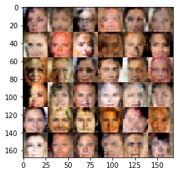

```
Epoch: 0     Step: 810   Dicriminator Loss: 0.790230   Generator Loss: 2.073229
Epoch: 0     Step: 820   Dicriminator Loss: 0.748053   Generator Loss: 1.958237
Epoch: 0     Step: 830   Dicriminator Loss: 0.915261   Generator Loss: 1.454418
Epoch: 0     Step: 840   Dicriminator Loss: 1.522371   Generator Loss: 0.398027
Epoch: 0     Step: 850   Dicriminator Loss: 0.893633   Generator Loss: 1.434267
Epoch: 0     Step: 860   Dicriminator Loss: 1.005825   Generator Loss: 0.948369
Epoch: 0     Step: 870   Dicriminator Loss: 0.880240   Generator Loss: 0.984825
Epoch: 0     Step: 880   Dicriminator Loss: 1.098672   Generator Loss: 0.685650
Epoch: 0     Step: 890   Dicriminator Loss: 1.099831   Generator Loss: 0.840119
Epoch: 0     Step: 900   Dicriminator Loss: 0.951052   Generator Loss: 0.955074
```

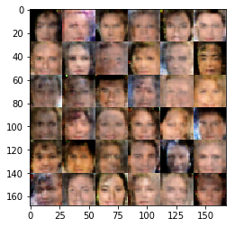

```
Epoch: 0     Step: 910   Dicriminator Loss: 0.940714   Generator Loss: 1.277576
Epoch: 0     Step: 920   Dicriminator Loss: 0.885828   Generator Loss: 1.100419
Epoch: 0     Step: 930   Dicriminator Loss: 1.085748   Generator Loss: 0.756768
Epoch: 0     Step: 940   Dicriminator Loss: 1.059549   Generator Loss: 0.809684
Epoch: 0     Step: 950   Dicriminator Loss: 1.056817   Generator Loss: 0.788381
Epoch: 0     Step: 960   Dicriminator Loss: 0.989972   Generator Loss: 1.000450
Epoch: 0     Step: 970   Dicriminator Loss: 1.335611   Generator Loss: 0.496559
Epoch: 0     Step: 980   Dicriminator Loss: 0.943949   Generator Loss: 1.852599
Epoch: 0     Step: 990   Dicriminator Loss: 1.241698   Generator Loss: 0.551262
Epoch: 0     Step: 1000  Dicriminator Loss: 1.274223   Generator Loss: 0.585034
```

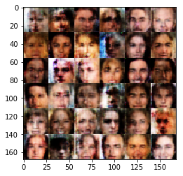

```
Epoch: 0     Step: 1010  Dicriminator Loss: 0.964738   Generator Loss: 1.156506
Epoch: 0     Step: 1020  Dicriminator Loss: 1.404773   Generator Loss: 0.503809
Epoch: 0     Step: 1030  Dicriminator Loss: 1.284434   Generator Loss: 0.592815
Epoch: 0     Step: 1040  Dicriminator Loss: 1.138906   Generator Loss: 0.677849
Epoch: 0     Step: 1050  Dicriminator Loss: 0.876646   Generator Loss: 1.274380
Epoch: 0     Step: 1060  Dicriminator Loss: 0.895100   Generator Loss: 1.077004
Epoch: 0     Step: 1070  Dicriminator Loss: 1.705012   Generator Loss: 0.306364
Epoch: 0     Step: 1080  Dicriminator Loss: 0.980040   Generator Loss: 1.605835
Epoch: 0     Step: 1090  Dicriminator Loss: 1.053364   Generator Loss: 1.152764
Epoch: 0     Step: 1100  Dicriminator Loss: 1.070071   Generator Loss: 0.886961
```

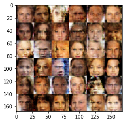

```
Epoch: 0     Step: 1110  Dicriminator Loss: 0.935358   Generator Loss: 1.256786
Epoch: 0     Step: 1120  Dicriminator Loss: 1.003308   Generator Loss: 1.029500
Epoch: 0     Step: 1130  Dicriminator Loss: 1.108851   Generator Loss: 0.724373
Epoch: 0     Step: 1140  Dicriminator Loss: 1.417800   Generator Loss: 0.856512
Epoch: 0     Step: 1150  Dicriminator Loss: 1.081527   Generator Loss: 0.940298
Epoch: 0     Step: 1160  Dicriminator Loss: 1.138597   Generator Loss: 0.864111
Epoch: 0     Step: 1170  Dicriminator Loss: 1.085162   Generator Loss: 1.079862
Epoch: 0     Step: 1180  Dicriminator Loss: 0.927236   Generator Loss: 1.298518
Epoch: 0     Step: 1190  Dicriminator Loss: 1.007875   Generator Loss: 1.753172
Epoch: 0     Step: 1200  Dicriminator Loss: 0.864351   Generator Loss: 1.288560
```

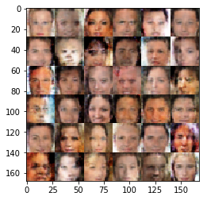

```
Epoch: 0     Step: 1210  Dicriminator Loss: 0.978565   Generator Loss: 1.652238
Epoch: 0     Step: 1220  Dicriminator Loss: 1.074911   Generator Loss: 0.826265
Epoch: 0     Step: 1230  Dicriminator Loss: 1.124263   Generator Loss: 0.813699
Epoch: 0     Step: 1240  Dicriminator Loss: 1.154119   Generator Loss: 1.645827
Epoch: 0     Step: 1250  Dicriminator Loss: 0.977996   Generator Loss: 1.513451
Epoch: 0     Step: 1260  Dicriminator Loss: 0.611024   Generator Loss: 1.859161
Epoch: 0     Step: 1270  Dicriminator Loss: 1.131904   Generator Loss: 0.828411
Epoch: 0     Step: 1280  Dicriminator Loss: 1.076812   Generator Loss: 0.999439
Epoch: 0     Step: 1290  Dicriminator Loss: 0.946141   Generator Loss: 1.003353
Epoch: 0     Step: 1300  Dicriminator Loss: 1.486626   Generator Loss: 0.453352
```

[3 more figures not shown]

```
Epoch: 0     Step: 1510  Dicriminator Loss: 1.093729   Generator Loss: 0.913427
Epoch: 0     Step: 1520  Dicriminator Loss: 1.047530   Generator Loss: 1.225860
Epoch: 0     Step: 1530  Dicriminator Loss: 0.948287   Generator Loss: 1.870980
Epoch: 0     Step: 1540  Dicriminator Loss: 1.204439   Generator Loss: 0.749849
Epoch: 0     Step: 1550  Dicriminator Loss: 1.136233   Generator Loss: 0.704572
Epoch: 0     Step: 1560  Dicriminator Loss: 1.306028   Generator Loss: 1.127797
Epoch: 0     Step: 1570  Dicriminator Loss: 1.144779   Generator Loss: 1.195672
Epoch: 0     Step: 1580  Dicriminator Loss: 1.145862   Generator Loss: 0.853230
```

```python
batch_size = 128
z_dim = 100
learning_rate = 0.0002
beta1 = 0.5


"""
DON'T MODIFY ANYTHING IN THIS CELL THAT IS BELOW THIS LINE
"""
epochs = 1

celeba_dataset = helper.Dataset('celeba', glob(os.path.join(data_dir, 'img_align_celeba/*.jpg')))
with tf.Graph().as_default():
    train(epochs, batch_size, z_dim, learning_rate, beta1, celeba_dataset.get_batches,
          celeba_dataset.shape, celeba_dataset.image_mode)
```

### Submitting This Project

When submitting this project, make sure to run all the cells before saving the notebook. Save the notebook file as "dlnd_face_generation.ipynb" and save it as a HTML file under "File" -> "Download as". Include the "helper.py" and "problem_unittests.py" files in your submission.